# One shared process, many sensors: multi-response mvgam

Nicholas J Clark

2026-06-26

Field monitoring rarely produces a single response variable. An ecologist counting animals along a transect typically also operates a baited trap and runs a camera array. Each survey delivers a noisy, partial view of the same underlying ecological quantity. Standard methods for time series data either fit each response separately, throwing away the information sitting in the other methods’ columns, or force every column into the same Gaussian observation model, which is wrong for counts, for biomass and for detection records. This article walks through the mvgam alternative: one shared latent dynamic process linked to many response variables, each with its own observation family and per-outcome covariates. The latent state is informed jointly by every response through the likelihood. We demonstrate this on a simulated three-method monitoring scenario where we know the truth and can verify recovery directly.

## The data

We simulate a single hypothetical animal population observed over 80 monthly time points by three parallel survey methods. The underlying latent state `x[t]` follows a stationary AR(1) with `phi = 0.7` and `sigma = 0.4`. Each method observes that state through a different measurement process:

- `count`: visual transect counts (Poisson, log link). Survey effort is logged each month and enters the linear predictor as an offset.
- `biomass`: trap-collected biomass per unit night (Gamma, log link). A cyclic seasonal smooth captures the natural seasonal rhythm in biomass independent of survey effort.
- `camera`: camera-trap presence/absence (Bernoulli, logit link). The number of deployment days enters as a linear slope.

The camera array is operated on a sparser schedule than the other two: only 60 of the 80 months carry camera observations. mvgam keeps the camera outcome on its own non-NA rows so the shared latent state is still informed during the 20 months without a camera by counts and biomass alone.

```r
mv_data <- read_cache("mv_data")
truth   <- read_cache("truth")
str(mv_data, give.attr = FALSE)
```

```
#> 'data.frame':    80 obs. of  8 variables:
#>  $ time       : int  1 2 3 4 5 6 7 8 9 10 ...
#>  $ series     : Factor w/ 1 level "pop1": 1 1 1 1 1 1 1 1 1 1 ...
#>  $ month      : int  1 2 3 4 5 6 7 8 9 10 ...
#>  $ log_effort : num  -0.171 0.102 0.127 -0.142 0.116 ...
#>  $ deploy_days: num  10.93 5.6 10.57 11.12 6.44 ...
#>  $ count      : int  11 10 7 8 9 11 14 7 2 1 ...
#>  $ biomass    : num  4.15 10.47 1.66 3.3 6.72 ...
#>  $ camera     : int  1 0 NA NA 1 0 1 1 1 1 ...
```

```r
cat("True phi      =", truth$phi,   "\n")
```

```
#> True phi      = 0.7
```

```r
cat("True sigma    =", truth$sigma, "\n")
```

```
#> True sigma    = 0.4
```

```r
cat("True nu       =", truth$nu,    "(Gamma shape)\n")
```

```
#> True nu       = 2 (Gamma shape)
```

```r
cat("camera obs    =", sum(!is.na(mv_data$camera)), "/", nrow(mv_data), "\n")
```

```
#> camera obs    = 60 / 80
```

A scatter of the three response columns by time shows what each method records and where the camera outcome is missing.

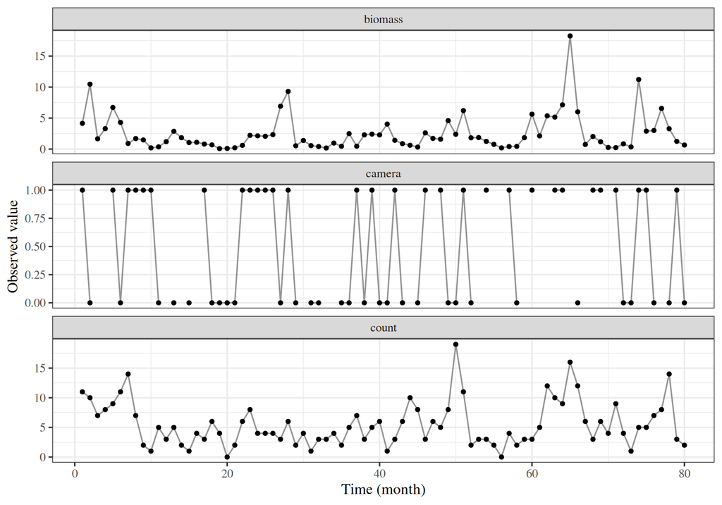

```r
long <- with(mv_data, rbind(
  data.frame(time = time, value = count,   resp = "count"),
  data.frame(time = time, value = biomass, resp = "biomass"),
  data.frame(time = time, value = camera,  resp = "camera")
))
ggplot(long, aes(x = time, y = value)) +
  geom_line(colour = "gray30", alpha = 0.6) +
  geom_point(size = 1.2, na.rm = TRUE) +
  facet_wrap(~ resp, ncol = 1L, scales = "free_y") +
  labs(x = "Time (month)", y = "Observed value")
```

## Three univariate baselines

To see how much the shared-process model gains over the default that fits each method alone, we first run three independent fits with the same AR(1) latent dynamics.

```r
mod_uni_count <- mvgam(
  count ~ 1 + offset(log_effort),
  trend_formula = ~ AR(p = 1),
  family = poisson(), data = mv_data,
  chains = 2L, samples = 1000L, silent = 2L
)
mod_uni_biomass <- mvgam(
  biomass ~ 1 + s(month, bs = "cc", k = 8),
  trend_formula = ~ AR(p = 1),
  family = Gamma(link = "log"), data = mv_data,
  knots = list(month = c(0.5, 12.5)),
  chains = 2L, samples = 1000L, silent = 2L
)
mod_uni_camera <- mvgam(
  camera ~ 1 + deploy_days,
  trend_formula = ~ AR(p = 1),
  family = bernoulli(link = "logit"), data = mv_data,
  chains = 2L, samples = 1000L, silent = 2L
)
```

Each fit converges (max R-hat below 1.05) but the camera outcome carries very little information by itself. The Bernoulli observations above provide only one bit per time point, so its AR(1) estimate of `x[t]` is correspondingly diffuse.

## A joint fit: one process, three observation families

The joint fit lives in one `mvgam()` call. We chain three `bf()` outcomes with the `+` operator (a brms idiom that mvgam re-exports). Each outcome gets its own family and its own predictors. Every outcome shares the same `trend_formula = ~ AR(p = 1)`: one latent state feeding three observation models.

```r
joint_formula <-
  bf(count   ~ 1 + offset(log_effort), family = poisson()) +
  bf(biomass ~ 1 + s(month, bs = "cc", k = 8),
     family = Gamma(link = "log")) +
  bf(camera  ~ 1 + deploy_days,
     family = bernoulli(link = "logit"))

mod_joint <- mvgam(
  joint_formula,
  trend_formula = ~ AR(p = 1),
  data  = mv_data,
  knots = list(month = c(0.5, 12.5)),
  chains = 2L, samples = 1000L, silent = 2L
)
```

mvgam handles the bookkeeping. brms’s default `mvbf` would drop those 20 rows from every outcome via listwise deletion. mvgam instead expands the standata so each outcome keeps its own non-NA rows. The Stan model then evaluates the count likelihood at all 80 time points, the biomass likelihood at all 80 and the camera likelihood at the 60 observed months, all contributing to a single shared AR(1) state.

The shared dynamics show up clearly in the fixed-effect summary and parameter recovery.

```r
s <- summary(mod_joint, smooth_test = FALSE)
print(s$spec)
```

```
#>               Estimate Est.Error l-95% CI u-95% CI    Rhat Bulk_ESS Tail_ESS
#> shape_biomass 2.566096 0.4748481 1.762931  3.63074 1.00014 1801.395 1439.579
```

```r
ps <- posterior_summary(mod_joint)
keep <- grep("Intercept|deploy_days|shape|ar1|sigma_trend",
              rownames(ps))
round(ps[keep, c("Estimate", "Q2.5", "Q97.5")], 3)
```

```
#>                      Estimate   Q2.5 Q97.5
#> Intercept_count         1.572  1.254 1.910
#> Intercept_biomass       0.589  0.266 0.939
#> shape_biomass           2.566  1.763 3.631
#> b_camera_deploy_days    0.080 -0.045 0.205
#> Intercept_camera        0.013 -0.586 0.618
#> sigma_trend[1]          0.438  0.316 0.571
#> ar1_trend[1]            0.634  0.377 0.859
#> b_count_Intercept       1.572  1.254 1.910
#> b_biomass_Intercept     0.589  0.266 0.939
#> b_camera_Intercept     -0.906 -2.477 0.604
```

Recovery against the truth (`phi = 0.7`, `sigma = 0.4`, `a_count = 1.5`, `a_biomass = 0.5`, `a_camera = -0.5`, `b_deploy = 0.05`, `nu = 2.0`) is clean: every intercept, the AR coefficient, the innovation SD and the Gamma shape sit close to their generating values with 95% intervals that cover.

## Posterior-predictive checks

Each outcome gets its own posterior-predictive check via the standard `pp_check()` interface, scoped with the `resp` argument. For the Bernoulli camera outcome the `"bars"` type is more informative than the default density overlay (which is built for continuous responses).

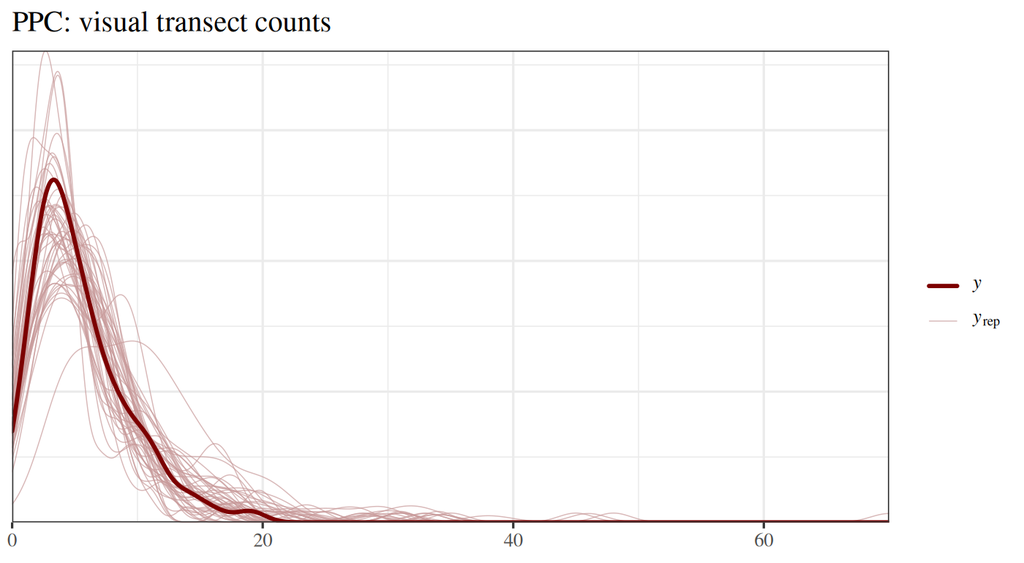

```r
pp_check(mod_joint, resp = "count", ndraws = 50L) +
  labs(title = "PPC: visual transect counts")
```

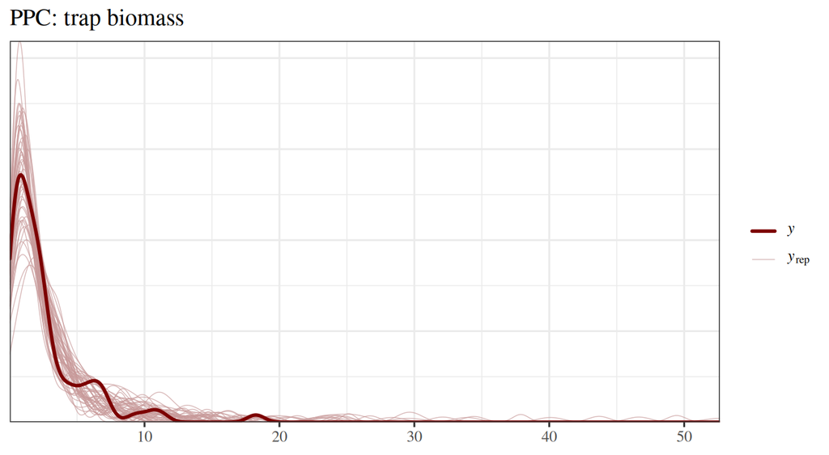

```r
pp_check(mod_joint, resp = "biomass", ndraws = 50L) +
  labs(title = "PPC: trap biomass")
```

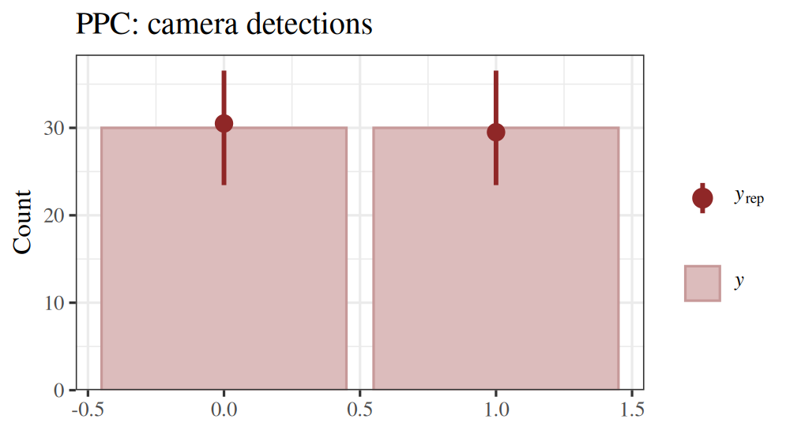

```r
pp_check(mod_joint, resp = "camera", type = "bars", ndraws = 50L) +
  labs(title = "PPC: camera detections")
```

The replicate distributions cover the observed marginals for every outcome. Calibration is sound on all three.

## Conditional effects

`conditional_effects()` returns one list per response, faceted internally by predictor. The plot for each outcome now carries the correct response on its y-axis.

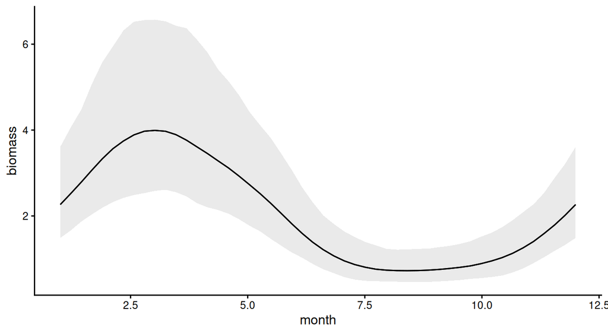

[figure not shown]

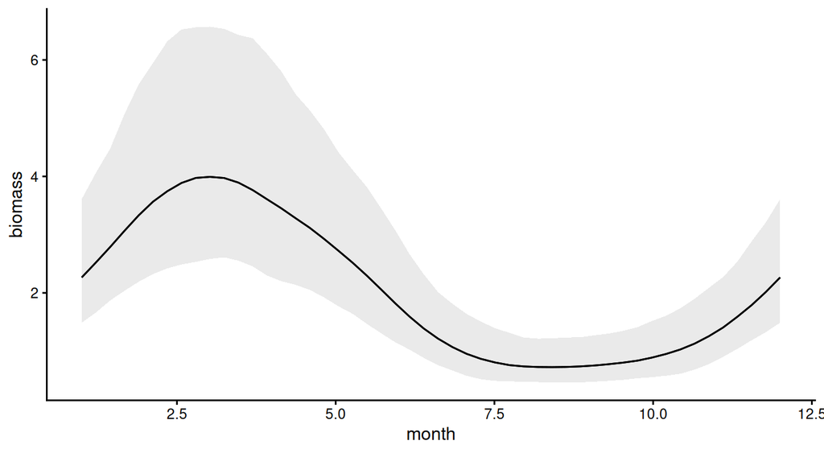

```r
ce <- mvgam::conditional_effects(mod_joint)
plot(ce[["biomass"]])[[1L]]
```

[figure not shown]

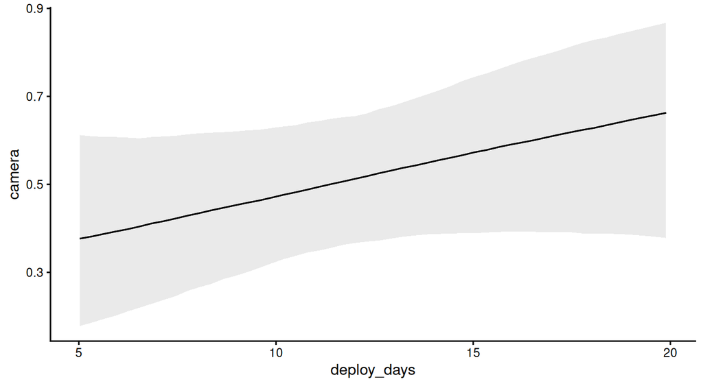

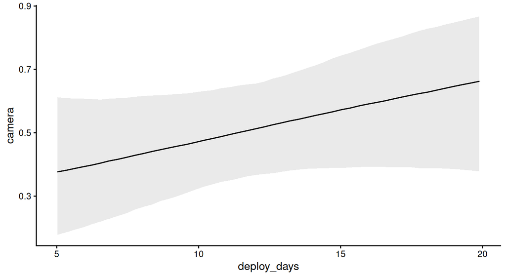

```r
plot(ce[["camera"]])[[2L]]
```

The camera outcome’s detection probability rises with deploy days, consistent with the simulated effect of 0.05 log-odds per day. The CI is wide because Bernoulli observations carry little information per row.

## Residual diagnostics

`plot(mod, type = "residuals", resp = X)` returns a four panel diagnostic of the Dunn-Smyth residuals for one outcome. The panels show residuals against fitted values, a Normal quantile plot, ACF and partial ACF. When the model is doing its job the residuals will sit horizontally around zero with no trend across the fitted range, will fall close to the quantile line and will show no autocorrelation lags reaching beyond the dashed bands.

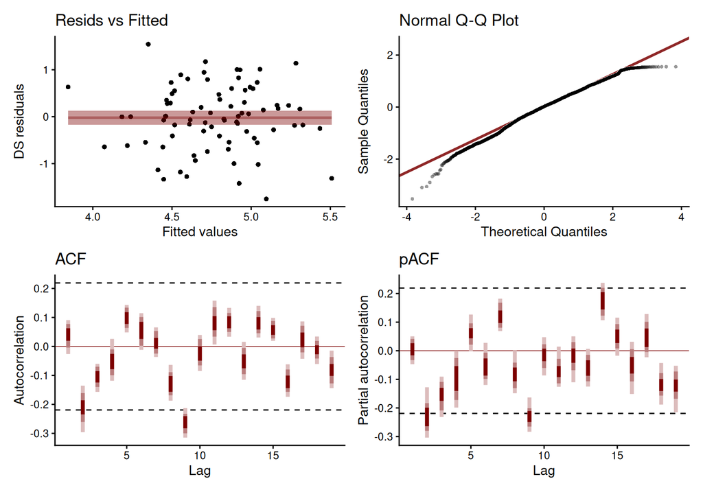

```r
plot(mod_joint, type = "residuals", resp = "count", ndraws = 100L)
```

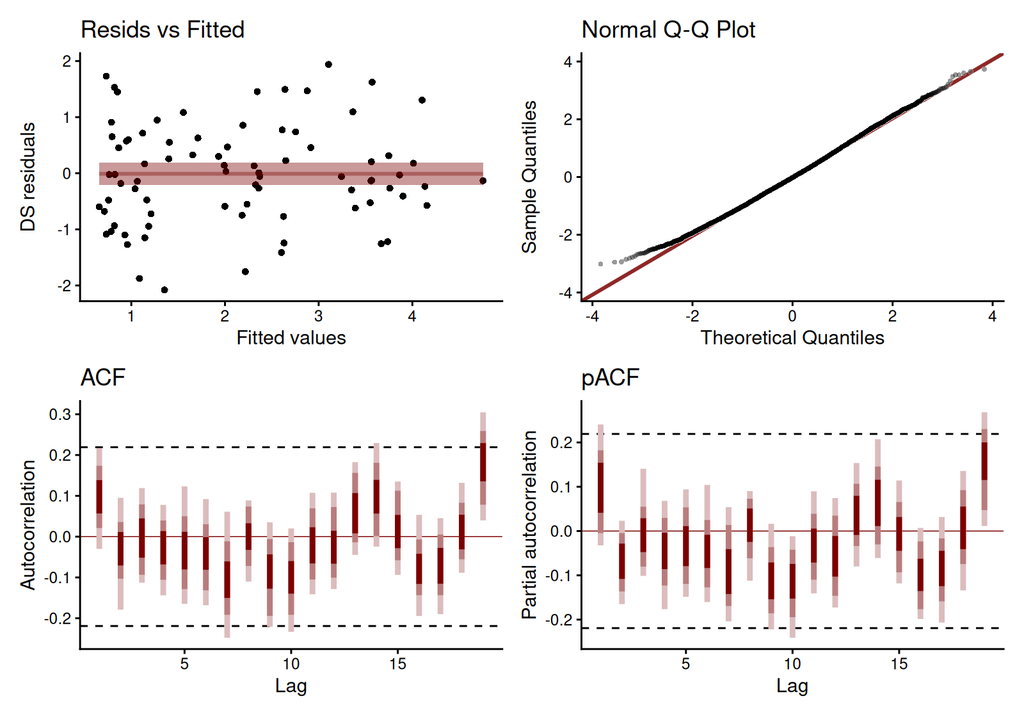

```r
plot(mod_joint, type = "residuals", resp = "biomass", ndraws = 100L)
```

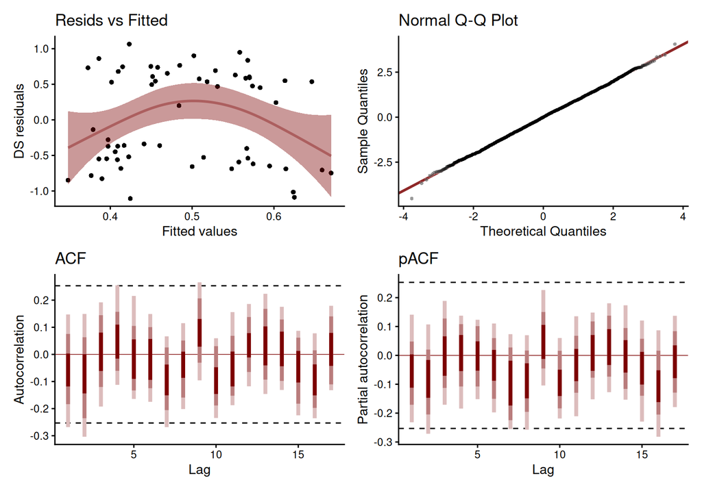

```r
plot(mod_joint, type = "residuals", resp = "camera", ndraws = 100L)
```

## State recovery: joint vs baselines

The point of the joint fit is the latent state itself. We pull the per-draw latent trajectory out of each fit with `hindcast(fit, type = "trend")`. The resulting `mvgam_forecast` plots with the package’s standard ribbon and median style. A `geom_point()` layer adds the simulated truth on top so recovery is read off directly.

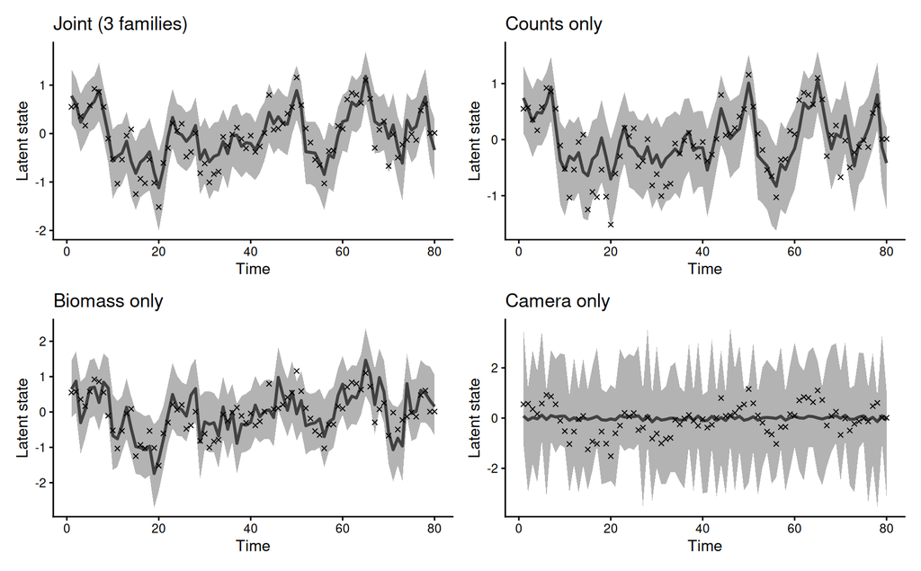

```r
fits <- list(
  "Joint (3 families)" = mod_joint,
  "Counts only"        = mod_uni_count,
  "Biomass only"       = mod_uni_biomass,
  "Camera only"        = mod_uni_camera
)
truth_pts <- data.frame(
  time = seq_along(truth$x), trend = truth$x
)

plot_recovery <- function(fit, label) {
  hc <- hindcast(fit, type = "trend")
  # Multi-response fits return one mvgam_forecast per outcome,
  # all sharing the same latent trend; the univariate fits return
  # a single mvgam_forecast directly.
  if (is.list(hc) && !inherits(hc, "mvgam_forecast")) {
    hc <- hc[[1L]]
  }
  # plot.mvgam_forecast overlays the response-scale observations
  # by default. On the trend scale those values live on a
  # different axis (Poisson counts up to 20 vs a latent state on
  # [-1, 1]); they would crush the ribbon flat. Drop the point
  # layer and overlay the simulated truth instead.
  p <- plot(hc)
  p$layers <- p$layers[!vapply(
    p$layers,
    function(l) inherits(l$geom, "GeomPoint"),
    logical(1L)
  )]
  p +
    geom_point(
      data = truth_pts,
      aes(x = time, y = trend),
      shape = 4, size = 1.2, colour = "black"
    ) +
    labs(title = label, y = "Latent state")
}

patchwork::wrap_plots(
  lapply(names(fits), function(n) plot_recovery(fits[[n]], n)),
  ncol = 2L
)
```

Two simple numbers back this up: the root mean squared error between the posterior median and the simulated truth at each time point, and the average posterior SD across time points. The first captures how close the median is to the truth; the second captures how tight the ribbon is.

```r
recovery_summary <- function(fit) {
  hc <- hindcast(fit, type = "trend")
  if (is.list(hc) && !inherits(hc, "mvgam_forecast")) hc <- hc[[1L]]
  m <- hc$hindcasts[[1L]]
  med <- apply(m, 2L, median)
  # Latent factor models identify the trend only up to sign; flip
  # the posterior to the sign that maximises correlation with the
  # truth before computing the recovery metrics.
  sgn <- sign(cor(med, truth$x))
  m <- sgn * m
  med <- sgn * med
  c(RMSE     = sqrt(mean((med - truth$x)^2)),
    `Mean SD` = mean(apply(m, 2L, sd)))
}
recovery <- t(sapply(fits, recovery_summary))
round(recovery, 3)
```

```
#>                     RMSE Mean SD
#> Joint (3 families) 0.255   0.321
#> Counts only        0.324   0.344
#> Biomass only       0.446   0.448
#> Camera only        0.569   0.982
```

The joint fit posts the smallest RMSE and the tightest mean SD; the camera-only fit is the outlier on both, because a single Bernoulli observation per time point carries little information. The joint fit borrows strength wherever any of the methods reported.

## Per-outcome posterior forecasts

The same `forecast()` interface that handles univariate fits now works on a multi-response fit: it fans out per response and returns one `mvgam_forecast` per outcome. We extend the time grid by 5 months and let mvgam propagate the shared latent state forward, then map back through each outcome’s observation family.

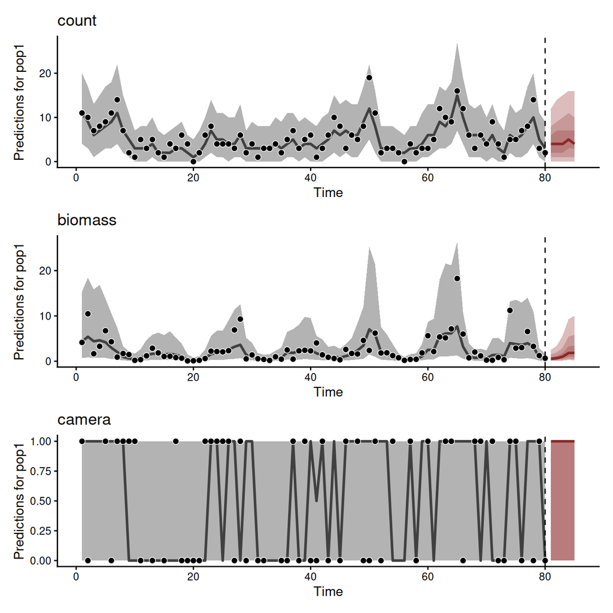

```r
T_ <- max(mv_data$time)
new <- data.frame(
  time = (T_ + 1L):(T_ + 5L),
  series = factor(rep("pop1", 5L), levels = levels(mv_data$series)),
  month = ((T_ + 0L:4L) %% 12L) + 1L,
  log_effort = log(rep(1, 5L)),
  deploy_days = rep(15, 5L),
  count = NA_integer_, biomass = NA_real_, camera = NA_integer_
)
fc <- forecast(mod_joint, newdata = new)
patchwork::wrap_plots(
  lapply(names(fc), function(n) plot(fc[[n]]) + labs(title = n)),
  ncol = 1L
)
```

Each panel shows that outcome’s posterior-predictive ribbon through the 80 training months and the 5 forecast months ahead. The same forecast objects feed straight into `score()`; see the [forecast evaluation article](https://nicholasjclark.github.io/mvgam/articles/forecast_evaluation.html) for the scoring rules and rolling-origin tools that pair with `forecast()` here.

## Take-aways

A multi-response mvgam fit lets each measurement model keep its proper observation family while sharing the dynamics that drive every series. The recipe is small: write one `bf()` block per response with its own family and predictors, combine the blocks with `+`, and pass the combined formula to `mvgam()` with a single shared `trend_formula = ~ ...`. Every post-fit method (`summary()`, `pp_check()`, `conditional_effects()`, `residuals()`, `posterior_predict()`, `forecast()`, `loo()`) either operates directly on the joint fit or accepts a `resp` argument that scopes the call to a single outcome. Outcomes with NA values keep their own non-NA rows, so the shared latent state is still informed at every time point any method actually reported.

This is the data integration idea applied to time series rather than to population vital rates: several noisy measurement processes pool into a single shared latent state, and every post-fit method downstream dispatches on that state with the `resp` argument to scope back to a single outcome.

## Further reading

The natural next functions to explore on the same fit are:

- `score()` and `ensemble()` for proper scoring rules and stacked weights on per-outcome forecasts.
- `lfo_cv()` for rolling-origin Bayesian leave-future-out cross-validation when the question is “how would this model have performed in production”.
- `loo()`, `kfold.mvgam()` and `posterior_average()` for in-sample model comparison and posterior-weighted predictions.
- `irf()`, `fevd()` and `stability()` for impulse response, forecast-error variance decomposition and stationarity diagnostics when the latent dynamics are a VAR.
- `methods_md()` for a citation-ready methods paragraph naming the architecture pieces the fit actually used.

Sibling articles in this series carry the workflow further:

- The [forecast evaluation article](https://nicholasjclark.github.io/mvgam/articles/forecast_evaluation.html) walks through `forecast()`, `score()`, `lfo_cv()` and `ensemble()` on a single count outcome and the multivariate scoring rules that pair with them.
- The [JSDM article](https://nicholasjclark.github.io/mvgam/articles/jsdgam.html) shows the joint-species variant where many response columns share a latent factor structure with informed priors via `jsdgam()`.
- For hierarchical or grouped trend dynamics (one shared trend per group with hyperpriors across groups), see `?gr` and the hierarchical-trends section of `vignette("mvgam_overview")`.

## Acknowledgements

The data integration framing draws on Schaub & Abadi ([2011](https://doi.org/10.1007/s10336-010-0632-7)). The latent dynamic perspective follows the review by Auger-Méthé and colleagues ([2021](https://doi.org/10.1002/ecm.1470)). The probabilistic backend is Stan (Carpenter et al. [2017](https://doi.org/10.18637/jss.v076.i01)) accessed through brms (Bürkner [2017](https://doi.org/10.18637/jss.v080.i01)).

## References

Auger-Méthé M, Newman K, Cole D, Empacher F, Gryba R, King AA, Leos-Barajas V, Mills Flemming J, Nielsen A, Petris G and Thomas L (2021). A guide to state-space modeling of ecological time series. *Ecological Monographs* 91(4), e01470. [doi:10.1002/ecm.1470](https://doi.org/10.1002/ecm.1470)

Bürkner P-C (2017). brms: An R Package for Bayesian Multilevel Models Using Stan. *Journal of Statistical Software* 80(1), 1-28. [doi:10.18637/jss.v080.i01](https://doi.org/10.18637/jss.v080.i01)

Carpenter B, Gelman A, Hoffman MD, Lee D, Goodrich B, Betancourt M, Brubaker M, Guo J, Li P and Riddell A (2017). Stan: A Probabilistic Programming Language. *Journal of Statistical Software* 76(1), 1-32. [doi:10.18637/jss.v076.i01](https://doi.org/10.18637/jss.v076.i01)

Schaub M and Abadi F (2011). Integrated population models: a novel analysis framework for deeper insights into population dynamics. *Journal of Ornithology* 152(Suppl 1), S227-S237. [doi:10.1007/s10336-010-0632-7](https://doi.org/10.1007/s10336-010-0632-7)